# Project: Investigate a Dataset (Replace this with something more specific!)

## let's take age column and sectors it to cateogries

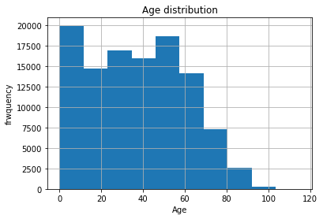

```python
df['Age'].hist()
plt.title('Age distribution')
plt.xlabel('Age')
plt.ylabel('frwquency');
```

```python
df['Age'].describe()
```

```
count    110526.000000
mean         37.089219
std          23.110026
min           0.000000
25%          18.000000
50%          37.000000
75%          55.000000
max         115.000000
Name: Age, dtype: float64
```

```python
# lets cutted the age into pices bassed on summary statistics
s=df['Age'].describe()[:].astype(int)
df['Age_sectors']=pd.cut(df['Age'],bins=[s['min']-1,s['25%'],s['50%'],s['75%'],s['max']],labels=['[0,19]','[20,39]','[40,57]','[58,115]'])
```

```python
# now we inserted after age
s=df.pop('Age_sectors')
df.insert(5,'Age_sectors',s)
```

```python
df.head()
```

|  | Gender | ScheduledDay | AppointmentDay | Days_diff | Age | Age_sectors | Neighbourhood | Scholarship | Hipertension | Diabetes | Alcoholism | Handcap | SMS_received | Show |
| --- | --- | --- | --- | --- | --- | --- | --- | --- | --- | --- | --- | --- | --- | --- |
| 0 | Female | 2016-04-29 18:38:08+00:00 | 2016-04-29 00:00:00+00:00 | -1 | 62 | [58,115] | JARDIM DA PENHA | False | True | False | False | False | NO | Yes |
| 1 | Male | 2016-04-29 16:08:27+00:00 | 2016-04-29 00:00:00+00:00 | -1 | 56 | [58,115] | JARDIM DA PENHA | False | False | False | False | False | NO | Yes |
| 2 | Female | 2016-04-29 16:19:04+00:00 | 2016-04-29 00:00:00+00:00 | -1 | 62 | [58,115] | MATA DA PRAIA | False | False | False | False | False | NO | Yes |
| 3 | Female | 2016-04-29 17:29:31+00:00 | 2016-04-29 00:00:00+00:00 | -1 | 8 | [0,19] | PONTAL DE CAMBURI | False | False | False | False | False | NO | Yes |
| 4 | Female | 2016-04-29 16:07:23+00:00 | 2016-04-29 00:00:00+00:00 | -1 | 56 | [58,115] | JARDIM DA PENHA | False | True | True | False | False | NO | Yes |

```python
# now let's summrize columns[Hipertension,Alcoholism,Diabetes] into one column called Disease
#using . any() which return true if any row of that column is true and return false if thre rows have false values

df.insert(11,'Disease',df[['Hipertension','Diabetes','Alcoholism']].any(axis=1))
df.head()
```

|  | Gender | ScheduledDay | AppointmentDay | Days_diff | Age | Age_sectors | Neighbourhood | Scholarship | Hipertension | Diabetes | Alcoholism | Disease | Handcap | SMS_received | Show |
| --- | --- | --- | --- | --- | --- | --- | --- | --- | --- | --- | --- | --- | --- | --- | --- |
| 0 | Female | 2016-04-29 18:38:08+00:00 | 2016-04-29 00:00:00+00:00 | -1 | 62 | [58,115] | JARDIM DA PENHA | False | True | False | False | True | False | NO | Yes |
| 1 | Male | 2016-04-29 16:08:27+00:00 | 2016-04-29 00:00:00+00:00 | -1 | 56 | [58,115] | JARDIM DA PENHA | False | False | False | False | False | False | NO | Yes |
| 2 | Female | 2016-04-29 16:19:04+00:00 | 2016-04-29 00:00:00+00:00 | -1 | 62 | [58,115] | MATA DA PRAIA | False | False | False | False | False | False | NO | Yes |
| 3 | Female | 2016-04-29 17:29:31+00:00 | 2016-04-29 00:00:00+00:00 | -1 | 8 | [0,19] | PONTAL DE CAMBURI | False | False | False | False | False | False | NO | Yes |
| 4 | Female | 2016-04-29 16:07:23+00:00 | 2016-04-29 00:00:00+00:00 | -1 | 56 | [58,115] | JARDIM DA PENHA | False | True | True | False | True | False | NO | Yes |

```python
# drop the 3 wanted columns
df.drop(labels=['Hipertension','Diabetes','Alcoholism'],inplace=True,axis=1)
df.head()
```

|  | Gender | ScheduledDay | AppointmentDay | Days_diff | Age | Age_sectors | Neighbourhood | Scholarship | Disease | Handcap | SMS_received | Show |
| --- | --- | --- | --- | --- | --- | --- | --- | --- | --- | --- | --- | --- |
| 0 | Female | 2016-04-29 18:38:08+00:00 | 2016-04-29 00:00:00+00:00 | -1 | 62 | [58,115] | JARDIM DA PENHA | False | True | False | NO | Yes |
| 1 | Male | 2016-04-29 16:08:27+00:00 | 2016-04-29 00:00:00+00:00 | -1 | 56 | [58,115] | JARDIM DA PENHA | False | False | False | NO | Yes |
| 2 | Female | 2016-04-29 16:19:04+00:00 | 2016-04-29 00:00:00+00:00 | -1 | 62 | [58,115] | MATA DA PRAIA | False | False | False | NO | Yes |
| 3 | Female | 2016-04-29 17:29:31+00:00 | 2016-04-29 00:00:00+00:00 | -1 | 8 | [0,19] | PONTAL DE CAMBURI | False | False | False | NO | Yes |
| 4 | Female | 2016-04-29 16:07:23+00:00 | 2016-04-29 00:00:00+00:00 | -1 | 56 | [58,115] | JARDIM DA PENHA | False | True | False | NO | Yes |

## Exploratory Data Analysis

### First we will exploring about the columns to get some insights

#### Q1)what is the more frequently month and year of the weeks of both scadual and appointmrnt columns

```
the more frequently scadual month is May
the more frequently appointment month is May
```

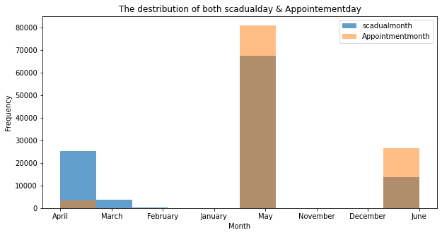

```python
print("the more frequently scadual month is {}".format(df['ScheduledDay'].dt.month_name().value_counts().idxmax()))
print("the more frequently appointment month is {}".format(df['AppointmentDay'].dt.month_name().value_counts().idxmax()))
plt.figure(figsize=(10, 5))
plt.figure(figsize=(10, 5))
plt.hist(x=df['ScheduledDay'].dt.month_name(),label='scadualmonth',alpha=0.7)
plt.hist(x=df['AppointmentDay'].dt.month_name(),label='Appointmentmonth',alpha=0.5)
plt.xlabel('Month')
plt.ylabel('Frequency')
plt.title('The destribution of both scadualday & Appointementday')
plt.legend(loc='upper right') ;
```

```python
df['ScheduledDay'].dt.day_name().value_counts()
```

```
Tuesday      26168
Wednesday    24262
Monday       23084
Friday       18915
Thursday     18073
Saturday        24
Name: ScheduledDay, dtype: int64
```

```
the more frequently scadual day is Tuesday
the more frequently appointment day is Wednesday
```

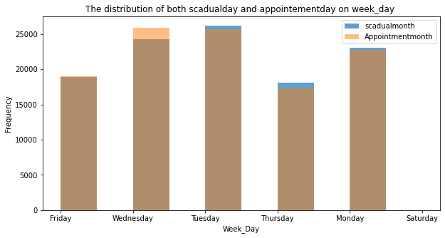

```python
print("the more frequently scadual day is {}".format(df['ScheduledDay'].dt.day_name().value_counts().idxmax()))
print("the more frequently appointment day is {}".format(df['AppointmentDay'].dt.day_name().value_counts().idxmax()))
plt.figure(figsize=(10, 5))
plt.figure(figsize=(10, 5))
plt.hist(x=df['ScheduledDay'].dt.day_name(),label='scadualmonth',alpha=0.7)
plt.hist(x=df['AppointmentDay'].dt.day_name(),label='Appointmentmonth',alpha=0.5)
plt.xlabel('Week_Day')
plt.ylabel('Frequency')
plt.title('The distribution of both scadualday and appointementday on week_day ')
plt.legend(loc='upper right') ;
```

#### Q1 coclusion is:

the more dense in both scadual and appointement is may but in case of days more dense are both Tuesday and Wednesday but in saturday approximatly no scadual and appoitement so we can recognize tha saturday is th vaction In brazil

> In that data sets we need to anylsis columns effect on the Show columns so we need to ask questions based on Show column

## Q2) What is sector of Age_sectors apeear to Show appointement more ?

> first we need to know the distribution of each sector

> let's define three varible that it will help us when anylasis the data

```python
data_length=df.shape[0]
data_show_yes_length=len(df.query('Show=="Yes"'))
data_show_no_length=len(df.query('Show=="NO"'))
```

```
distribution of Age_sectors
 [0,19]      0.261169
[58,115]    0.248846
[20,39]     0.246548
[40,57]     0.243436
Name: Age_sectors, dtype: float64
```

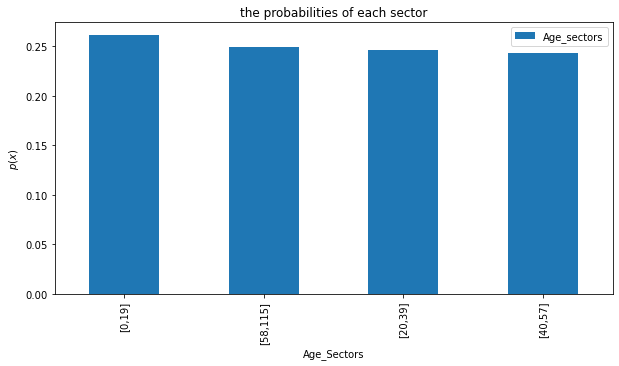

```python
# so now let's visulize distribution of Age_sectors
print("distribution of Age_sectors\n {}".format(df['Age_sectors'].value_counts()/data_length))
plt.figure(figsize=(10, 5))
(df['Age_sectors'].value_counts()/data_length).plot(kind='bar')
plt.xlabel('Age_Sectors')
plt.ylabel(r'$p(x)$')
plt.title('the probabilities of each sector')
plt.legend(loc='upper right') ;
```

> as we show distribution of all 4 cateogries have the same weight so that what we expected

> because we sectors data bassed on min,25%,%50,75% and max which sectors data to 4 equal

### now let's test those sectors on Show Appoitement

```
distribution of Age_sectors given that Show is yes
 [58,115]    0.263029
[0,19]      0.255297
[40,57]     0.245457
[20,39]     0.236217
Name: Age_sectors, dtype: float64
```

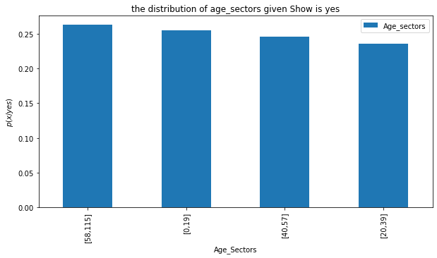

```python
print("distribution of Age_sectors given that Show is yes\n {}".format(df.query('Show=="Yes"')['Age_sectors'].value_counts()/data_show_yes_length))
plt.figure(figsize=(10, 5))
(df.query('Show=="Yes"')['Age_sectors'].value_counts()/data_show_yes_length).plot(kind='bar')
plt.xlabel('Age_Sectors')
plt.ylabel(r'$p(x/yes)$')
plt.title('the distribution of age_sectors given Show is yes')
plt.legend(loc='upper right') ;
```

```
[0,19]      0.261169
[58,115]    0.248846
[20,39]     0.246548
[40,57]     0.243436
Name: Age_sectors, dtype: float64
```

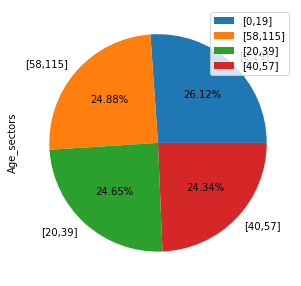

```python
plt.figure(figsize=(10, 5))
print(df['Age_sectors'].value_counts()/data_length)
plt.figure(figsize=(10, 5))
df['Age_sectors'].value_counts().plot(kind='pie',autopct='%1.2f%%') ;
plt.legend(loc='upper right') ;
```

```
distribution of Age_sectors given that Show is NO
 [20,39]     0.287378
[0,19]      0.284377
[40,57]     0.235450
[58,115]    0.192795
Name: Age_sectors, dtype: float64
```

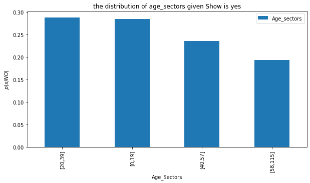

```python
print("distribution of Age_sectors given that Show is NO\n {}".format(df.query('Show=="NO"')['Age_sectors'].value_counts()/data_show_no_length))
plt.figure(figsize=(10, 5))
(df.query('Show=="NO"')['Age_sectors'].value_counts()/data_show_no_length).plot(kind='bar')
plt.xlabel('Age_Sectors')
plt.ylabel(r'$p(x/NO)$')
plt.title('the distribution of age_sectors given Show is yes')
plt.legend(loc='upper right') ;
```

```
Show  Age_sectors
NO    [20,39]         6414
      [0,19]          6347
      [40,57]         5255
      [58,115]        4303
Yes   [58,115]       23201
      [0,19]         22519
      [40,57]        21651
      [20,39]        20836
Name: Age_sectors, dtype: int64
```

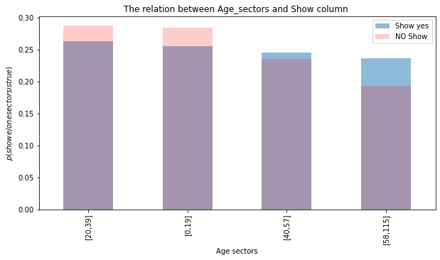

```python
### let's now show whole data in one figure
print(df.groupby(['Show'])['Age_sectors'].value_counts())
plt.figure(figsize=(10, 5))
(df.query('Show=="Yes"')['Age_sectors'].value_counts()/data_show_yes_length).plot(kind='bar',alpha=0.5,label="Show yes")
(df.query('Show=="NO"')['Age_sectors'].value_counts()/data_show_no_length).plot(kind='bar',color='r',alpha=0.2,label="NO Show",)
plt.xlabel("Age sectors")
plt.ylabel(r'$p(showe/one sectorsis true)$')
plt.title('The relation between Age_sectors and Show column ')
plt.legend(loc='upper right') ;
```

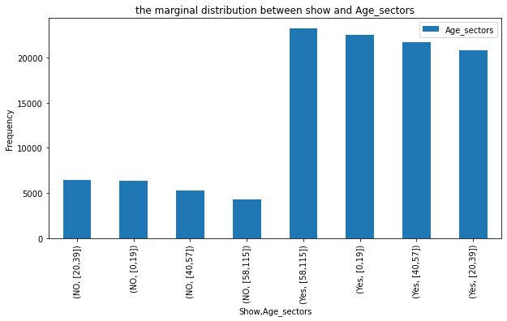

```python
# or can make in one plot like that
plt.figure(figsize=(10, 5))
plt.title('the marginal distribution between show and Age_sectors')
plt.ylabel('Frequency')
df.groupby(['Show'])['Age_sectors'].value_counts().plot(kind='bar')
plt.legend(loc='upper right') ;
```

### The conclusion here of Q2)a)

> x here pointed to Age_sectors

> in case of p(x/Show=yes) the all four sectors aprroximatly the same

> but in the case of p(x/Show=NO) the two sectors [20,39] and [0,19] to not show more than two other sectors

> another one conclusion is patients in various sectors ateend the appointement

### Q3) what happened if we take intrest of Gender column with Age_sectors on Show column ?

> first we need to know statistics of Gender first

```
Female    0.649974
Male      0.350026
Name: Gender, dtype: float64
```

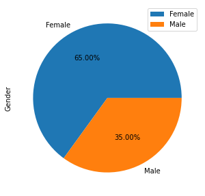

```python
plt.figure(figsize=(10, 5))
print(df['Gender'].value_counts()/data_length)
plt.figure(figsize=(10, 5))
df['Gender'].value_counts().plot(kind='pie',autopct='%1.2f%%') ;
plt.legend(loc='upper right') ;
```

### Hint

> well the data is biased toword Female than Male that it maybe affects on our insights of this data on Show cloumn

> so now we study the efeects of Gender and Age_sectors on Show column

> so let's show and visulize the table of Show appointement bassed on Gender

```
Gender  Show
Female  Yes     57245
        NO      14594
Male    Yes     30962
        NO       7725
Name: Show, dtype: int64
```

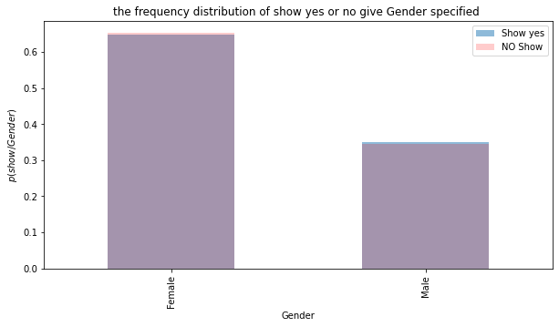

```python
### let's now show whole data in one figure
print(df.groupby(['Gender'])['Show'].value_counts())
plt.figure(figsize=(10, 5))
(df.query('Show=="Yes"')['Gender'].value_counts()/data_show_yes_length).plot(kind='bar',alpha=0.5,label="Show yes")
(df.query('Show=="NO"')['Gender'].value_counts()/data_show_no_length).plot(kind='bar',color='r',alpha=0.2,label="NO Show",)
plt.xlabel("Gender")
plt.ylabel(r'$p(show/Gender)$')
plt.title("the frequency distribution of show yes or no give Gender specified ")
plt.legend(loc='upper right') ;
```

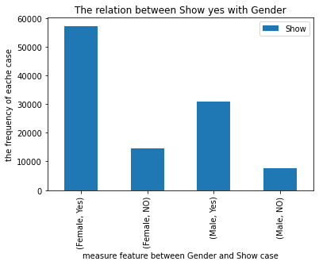

```python
#or can make it in only one plot
df.groupby(['Gender'])['Show'].value_counts().plot(kind='bar')
plt.xlabel('measure feature between Gender and Show case')
plt.ylabel("the frequency of eache case")
plt.title('The relation between Show yes with Gender')
plt.legend(loc='upper right') ;
```

> The conclusion from last figure is for both show and no show both female has frequently more than male

> but cannot tell the female show appointement greater than male because our original datset biased toword Female than Male

#### So let's try make some enhancement to avoid this false insights

> this defined function take series data and get it's recoplical of each to make some enhancement of our insights in case of male and female the data is biased toword female so we get factor we can multiply on rersults to get better insight and reduced biased

```python
def get_enhance(data):
    for i in data.index:
        data[i]=np.reciprocal(data[i])
    data.rename(index=lambda x:x+'_enhance',inplace=True)
    return data
```

```python
data=df['Gender'].value_counts()/data_length
print(get_enhance(data))
```

```
Female_enhance    1.538524
Male_enhance      2.856929
Name: Gender, dtype: float64
```

```
Gender  Show
Female  Yes     57245
        NO      14594
Male    Yes     30962
        NO       7725
Name: Show, dtype: int64
```

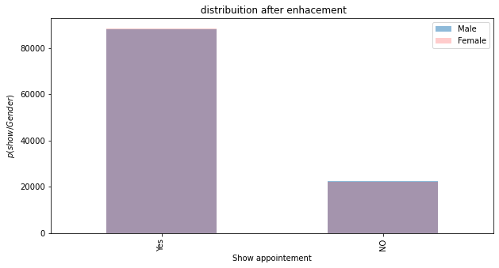

```python
## let's now show whole data in one figure
print(df.groupby(['Gender'])['Show'].value_counts())
plt.figure(figsize=(10, 5))
(df.query('Gender=="Female"')['Show'].value_counts()*data['Female_enhance']).plot(kind='bar',alpha=0.5,label="Male")
(df.query('Gender=="Male"')['Show'].value_counts()*data['Male_enhance']).plot(kind='bar',color='r',alpha=0.2,label="Female",)
plt.xlabel("Show appointement")
plt.ylabel(r'$p(show/Gender)$')
plt.title(" distribuition after enhacement")
plt.legend(loc='upper right') ;
```

```python
np.rint(df.query('Gender=="Female"')['Show'].value_counts()*data['Female_enhance'])/data_length
```

```
Yes    0.796853
NO     0.203147
Name: Show, dtype: float64
```

```python
np.rint(df.query('Gender=="Male"')['Show'].value_counts()*data['Male_enhance'])/data_length
```

```
Yes    0.800318
NO     0.199682
Name: Show, dtype: float64
```

> comment: the enhancement here is multiple frequencies to make data not biased to male and female so the conclusion it almost look the same probabiliuty of male and female to show or not show the appointement

#### now let's make all gender age_sectors and show in same plot

```
Gender  Age_sectors  Show
Female  [0,19]       Yes     11644
                     NO       3310
        [20,39]      Yes     15154
                     NO       4668
        [40,57]      Yes     14867
                     NO       3637
        [58,115]     Yes     15580
                     NO       2979
Male    [0,19]       Yes     10875
                     NO       3037
        [20,39]      Yes      5682
                     NO       1746
        [40,57]      Yes      6784
                     NO       1618
        [58,115]     Yes      7621
                     NO       1324
Name: Show, dtype: int64
```

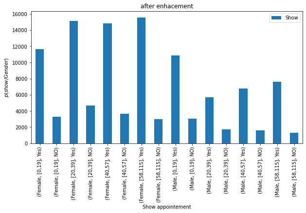

```python
print(df.groupby(['Gender','Age_sectors'],sort=True)['Show'].value_counts())
plt.figure(figsize=(10, 5))
df.groupby(['Gender','Age_sectors'],sort=True)['Show'].value_counts().plot(kind='bar')
plt.xlabel("Show appointement")
plt.ylabel(r'$p(show/Gender)$')
plt.title("after enhacement")
plt.legend(loc='upper right') ;
```

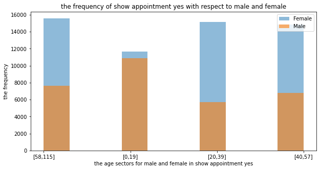

```python
# let's make the visulization of yes appointment yes which shows two indpendat variable on one dependat
# variable which is show
plt.figure(figsize=(10, 5))
plt.hist(x=df[(df['Gender']=="Female")&(df['Show']=="Yes")]["Age_sectors"],label="Female",alpha=0.5)
plt.hist(df[(df['Gender']=="Male")&(df['Show']=="Yes")]["Age_sectors"],label="Male",alpha=0.6)
plt.xlabel('the age sectors for male and female in show appointment yes')
plt.ylabel("the frequency")
plt.title("the frequency of show appointment yes with respect to male and female")
plt.legend(loc='upper right')
plt.show()
```

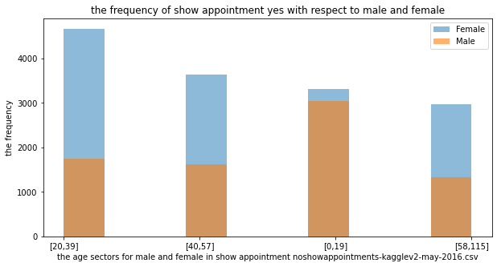

```python
# let's make the visulization of yes appointment yes which shows two indpendat variable on one dependat
# variable which is show
plt.figure(figsize=(10, 5))
plt.hist(x=df[(df['Gender']=="Female")&(df['Show']=="NO")]["Age_sectors"],label="Female",alpha=0.5)
plt.hist(df[(df['Gender']=="Male")&(df['Show']=="NO")]["Age_sectors"],label="Male",alpha=0.6)
plt.xlabel('the age sectors for male and female in show appointment noshowappointments-kagglev2-may-2016.csv')
plt.ylabel("the frequency")
plt.title("the frequency of show appointment yes with respect to male and female")
plt.legend(loc='upper right')
plt.show()
```

### Q3) conclusion

> female shows appoint ment in the three cateogries [20,39] , [40,57],[58,115] approximatly the same

> but male shows appointement more in sector [0,19] which what we not expected

> female not show is nmore in sector [20,39] more than remaning sectors

> male in no show in [0,19] more than remaning sectors

```python
df.head()
```

|  | Gender | ScheduledDay | AppointmentDay | Days_diff | Age | Age_sectors | Neighbourhood | Scholarship | Disease | Handcap | SMS_received | Show |
| --- | --- | --- | --- | --- | --- | --- | --- | --- | --- | --- | --- | --- |
| 0 | Female | 2016-04-29 18:38:08+00:00 | 2016-04-29 00:00:00+00:00 | -1 | 62 | [58,115] | JARDIM DA PENHA | False | True | False | NO | Yes |
| 1 | Male | 2016-04-29 16:08:27+00:00 | 2016-04-29 00:00:00+00:00 | -1 | 56 | [58,115] | JARDIM DA PENHA | False | False | False | NO | Yes |
| 2 | Female | 2016-04-29 16:19:04+00:00 | 2016-04-29 00:00:00+00:00 | -1 | 62 | [58,115] | MATA DA PRAIA | False | False | False | NO | Yes |
| 3 | Female | 2016-04-29 17:29:31+00:00 | 2016-04-29 00:00:00+00:00 | -1 | 8 | [0,19] | PONTAL DE CAMBURI | False | False | False | NO | Yes |
| 4 | Female | 2016-04-29 16:07:23+00:00 | 2016-04-29 00:00:00+00:00 | -1 | 56 | [58,115] | JARDIM DA PENHA | False | True | False | NO | Yes |

## Q4) what is the relatioship between chronic disease and alcoholic on Show column ?

> in the data wrangling section i combined Hipertension diabatic and alchole int one column called disease by oring the three columns which get some insights about patient with serious disease needed to take into our consideration

> first need to get the frequency of diases column

```
False    0.771864
True     0.228136
Name: Disease, dtype: float64
```

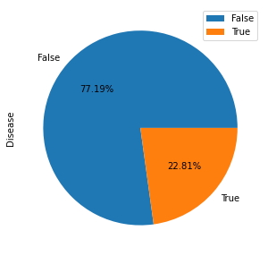

```python
plt.figure(figsize=(10, 5))
print(df['Disease'].value_counts()/data_length)
plt.figure(figsize=(10, 5))
df['Disease'].value_counts().plot(kind='pie',autopct='%1.2f%%') ;
plt.legend(loc='upper right') ;
```

> second let's know the relation between Age_sectors and Diases column

```
Disease  Age_sectors
False    [0,19]         28756
         [20,39]        25395
         [40,57]        18891
         [58,115]       12269
True     [58,115]       15235
         [40,57]         8015
         [20,39]         1855
         [0,19]           110
Name: Age_sectors, dtype: int64
```

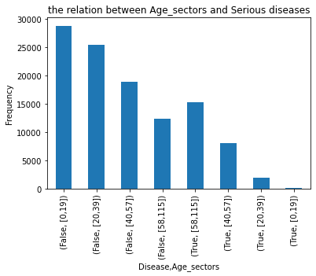

```python
print(df.groupby(['Disease'])['Age_sectors'].value_counts())
df.groupby(['Disease'])['Age_sectors'].value_counts().plot(kind='bar')
plt.ylabel('Frequency')
plt.title('the relation between Age_sectors and Serious diseases')
```

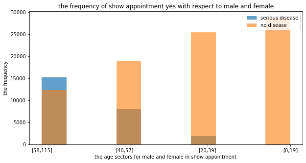

```python
plt.figure(figsize=(10, 5))
plt.hist(x=df[(df['Disease']==True)]["Age_sectors"],label="serious disease",alpha=0.7)
plt.hist(x=df[(df['Disease']==False)]["Age_sectors"],label="no disease",alpha=0.6)
plt.xlabel('the age sectors for male and female in show appointment ')
plt.ylabel("the frequency")
plt.title("the frequency of show appointment yes with respect to male and female")
plt.legend(loc='upper right')
plt.show()
```

> the conclusion from above two tables it show that serious disease in age_sector [58,115] then [40,75] as we expected

> now let's take the effects of age_sector , disaese is true on show column

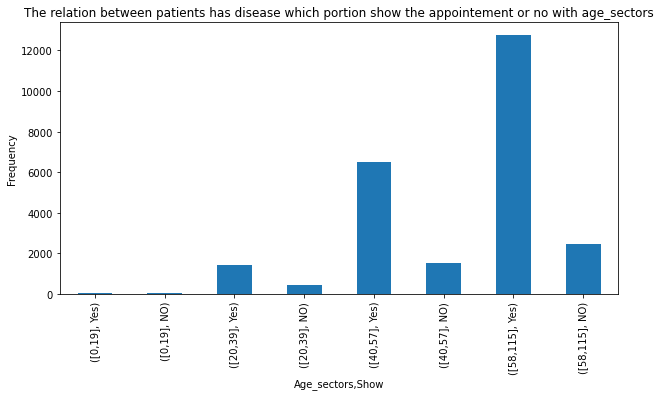

```python
plt.figure(figsize=(10, 5))
df.query('Disease==True').groupby(['Age_sectors'])['Show'].value_counts().plot(kind='bar')
plt.ylabel('Frequency')
plt.title('The relation between patients has disease which portion show the appointement or no with age_sectors')
```

```
the probabilties of show attendant has a disease be
 False    0.764939
True     0.235061
Name: Disease, dtype: float64
```

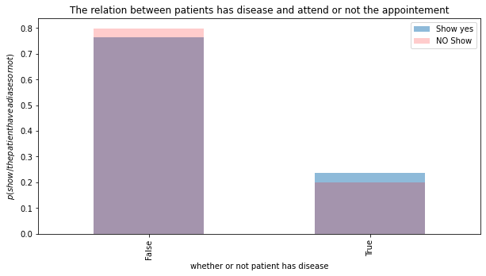

```python
### let's now show whole data in one figure
print("the probabilties of show attendant has a disease be \n",df.query('Show=="Yes"')['Disease'].value_counts()/data_show_yes_length)
plt.figure(figsize=(10, 5))
(df.query('Show=="Yes"')['Disease'].value_counts()/data_show_yes_length).plot(kind='bar',alpha=0.5,label="Show yes")
(df.query('Show=="NO"')['Disease'].value_counts()/data_show_no_length).plot(kind='bar',color='r',alpha=0.2,label="NO Show",)
plt.xlabel("whether or not patient has disease")
plt.ylabel(r'$p(show/the patient have a diases or not)$')
plt.title('The relation between patients has disease and attend or not the appointement')
plt.legend(loc='upper right') ;
```

> the probability (true disease/show yes) is approximatly 0.24

> now let's combined Age_sectors, Disease true or false and show appoitement in one figure

```
the probabilties of show attendant has a disease be
 Age_sectors  Disease
[0,19]       False      0.254504
             True       0.000794
[20,39]      False      0.220039
             True       0.016178
[40,57]      False      0.171948
             True       0.073509
[58,115]     True       0.144580
             False      0.118449
Name: Disease, dtype: float64
```

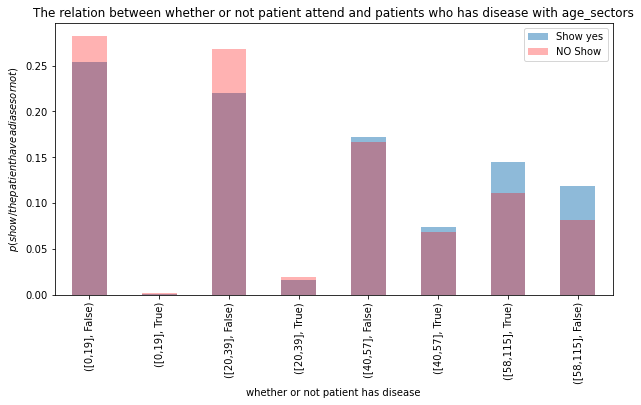

```python
print("the probabilties of show attendant has a disease be \n",df.query('Show=="Yes"').groupby(['Age_sectors'])['Disease'].value_counts()/data_show_yes_length)
plt.figure(figsize=(10, 5))
(df.query('Show=="Yes"').groupby(['Age_sectors'])['Disease'].value_counts()/data_show_yes_length).plot(kind='bar',alpha=0.5,label="Show yes")
(df.query('Show=="NO"').groupby(['Age_sectors'])['Disease'].value_counts()/data_show_no_length).plot(kind='bar',color='r',alpha=0.3,label="NO Show",)
plt.xlabel("whether or not patient has disease")
plt.ylabel(r'$p(show/the patient have a diases or not)$')
plt.title('The relation between whether or not patient attend and patients who has disease with age_sectors')
plt.legend(loc='upper right') ;
```

### Q4)conclusion

> from the figure above the more probability age_sectors to show up which have a serious disease is [58,115] sectors

> and in case of no disease the age_sector [0,19] has more to show up

## Q5) what is the relationship between Scholarship and Disease column on Show column

> First let's show Scholarship column

```
False    0.901734
True     0.098266
Name: Scholarship, dtype: float64
```

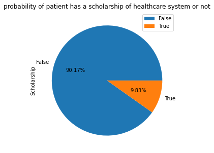

```python
plt.figure(figsize=(10, 5))
print(df['Scholarship'].value_counts()/data_length)
plt.figure(figsize=(10, 5))
df['Scholarship'].value_counts().plot(kind='pie',autopct='%1.2f%%') ;
plt.title('probability of patient has a scholarship of healthcare system or not')
plt.legend(loc='upper right') ;
```

> only approximatly 9.83 % of the patient datset has a scholarship in healthcare system

> let's test relation between scholarship and age_sectors

```
most frequently sectorbe  [20,39]
```

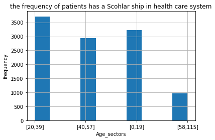

```python
### let's now show whole data in one figure
print('most frequently sectorbe ',df.query('Scholarship==True')['Age_sectors'].value_counts().idxmax())
df.query('Scholarship==True')['Age_sectors'].hist()
plt.xlabel('Age_sectors')
plt.ylabel('frequency')
plt.title('the frequency of patients has a Scohlar ship in health care system')
```

> conclusion from above the maost frequently sector is [20,39] but the minimum sector is [58,115] which mean a dengrous situiation and no data biased here because we sectroized data to overcome this biase

```python
# to test bised of sectors lets use our enhance function
get_enhance(df['Age_sectors'].value_counts(normalize=True))
#almost the same
```

```
[0,19]_enhance      3.828934
[58,115]_enhance    4.018543
[20,39]_enhance     4.056000
[40,57]_enhance     4.107857
Name: Age_sectors, dtype: float64
```

> now let's test scolarship with Show column

```
the probabilties of show attendant has a Scholarship be
 False    0.764939
True     0.235061
Name: Disease, dtype: float64
```

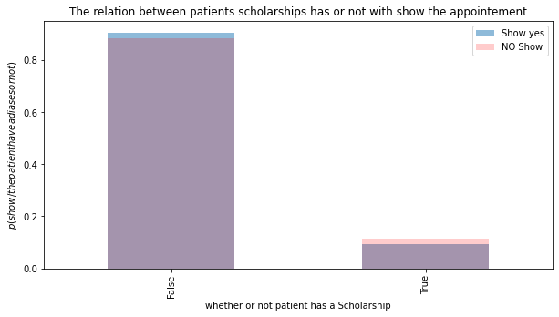

```python
### let's now show whole data in one figure
print("the probabilties of show attendant has a Scholarship be \n",df.query('Show=="Yes"')['Disease'].value_counts()/data_show_yes_length)
plt.figure(figsize=(10, 5))
(df.query('Show=="Yes"')['Scholarship'].value_counts()/data_show_yes_length).plot(kind='bar',alpha=0.5,label="Show yes")
(df.query('Show=="NO"')['Scholarship'].value_counts()/data_show_no_length).plot(kind='bar',color='r',alpha=0.2,label="NO Show",)
plt.xlabel("whether or not patient has a Scholarship")
plt.ylabel(r'$p(show/the patient have a diases or not)$')
plt.title('The relation between patients scholarships has or not with show the appointement')
plt.legend(loc='upper right') ;
```

```
the probabilties of show attendant has a disease be
 Age_sectors  Disease
[0,19]       False      0.254504
             True       0.000794
[20,39]      False      0.220039
             True       0.016178
[40,57]      False      0.171948
             True       0.073509
[58,115]     True       0.144580
             False      0.118449
Name: Disease, dtype: float64
```

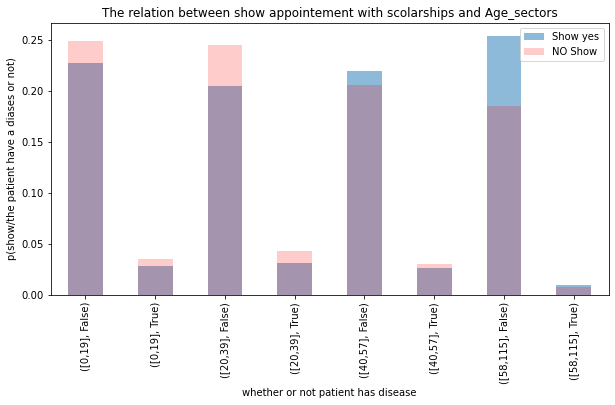

```python
print("the probabilties of show attendant has a disease be \n",df.query('Show=="Yes"').groupby(['Age_sectors'])['Disease'].value_counts()/data_show_yes_length)
plt.figure(figsize=(10, 5))
(df.query('Show=="Yes"').groupby(['Age_sectors'])['Scholarship'].value_counts()/data_show_yes_length).plot(kind='bar',alpha=0.5,label="Show yes")
(df.query('Show=="NO"').groupby(['Age_sectors'])['Scholarship'].value_counts()/data_show_no_length).plot(kind='bar',color='r',alpha=0.2,label="NO Show",)
plt.xlabel("whether or not patient has disease")
plt.ylabel('p(show/the patient have a diases or not)')
plt.title('The relation between show appointement with scolarships and Age_sectors')
plt.legend(loc='upper right') ;
```

#### Q)5 conclusion

> .more people with no scholarship shows appointement in sectors [40,57] and [58,115]

> .but in the age_sectors [0,19] and [20,39] patients doesnot show appointement relatied to no_show

> .the above results approximatly the same in a scholar shipcase

```python
df.head()
```

|  | Gender | ScheduledDay | AppointmentDay | Days_diff | Age | Age_sectors | Neighbourhood | Scholarship | Disease | Handcap | SMS_received | Show |
| --- | --- | --- | --- | --- | --- | --- | --- | --- | --- | --- | --- | --- |
| 0 | Female | 2016-04-29 18:38:08+00:00 | 2016-04-29 00:00:00+00:00 | -1 | 62 | [58,115] | JARDIM DA PENHA | False | True | False | NO | Yes |
| 1 | Male | 2016-04-29 16:08:27+00:00 | 2016-04-29 00:00:00+00:00 | -1 | 56 | [58,115] | JARDIM DA PENHA | False | False | False | NO | Yes |
| 2 | Female | 2016-04-29 16:19:04+00:00 | 2016-04-29 00:00:00+00:00 | -1 | 62 | [58,115] | MATA DA PRAIA | False | False | False | NO | Yes |
| 3 | Female | 2016-04-29 17:29:31+00:00 | 2016-04-29 00:00:00+00:00 | -1 | 8 | [0,19] | PONTAL DE CAMBURI | False | False | False | NO | Yes |
| 4 | Female | 2016-04-29 16:07:23+00:00 | 2016-04-29 00:00:00+00:00 | -1 | 56 | [58,115] | JARDIM DA PENHA | False | True | False | NO | Yes |

## Q6) Which Neighbourhood most frequently and does the more frequently Neighbourhood has no appointement than lower frequent?

> First let's test the frequency(Histogram) of Neighbourhood

```
most frequent 10 hospitals ['JARDIM CAMBURI', 'MARIA ORTIZ', 'RESISTÊNCIA', 'JARDIM DA PENHA', 'ITARARÉ', 'CENTRO', 'TABUAZEIRO', 'SANTA MARTHA', 'JESUS DE NAZARETH', 'BONFIM']
the most frequently hospital is JARDIM CAMBURI       0.069821
MARIA ORTIZ          0.052522
RESISTÊNCIA          0.040090
JARDIM DA PENHA      0.035078
ITARARÉ              0.031793
CENTRO               0.030165
TABUAZEIRO           0.028337
SANTA MARTHA         0.028328
JESUS DE NAZARETH    0.025813
BONFIM               0.025089
Name: Neighbourhood, dtype: float64
```

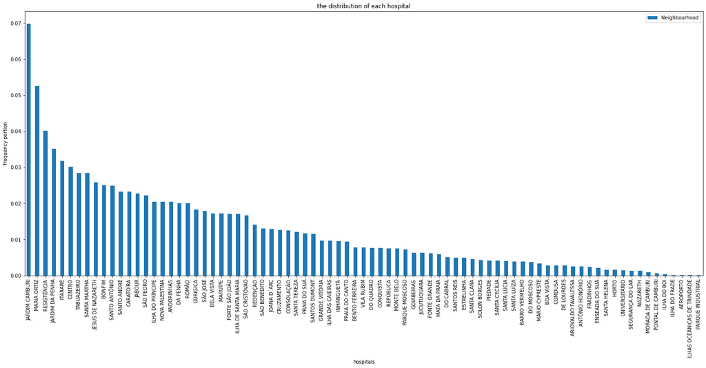

```python
max_10=df['Neighbourhood'].value_counts(normalize=True)[:10].index.tolist()
print('most frequent 10 hospitals',max_10)
print('the most frequently hospital is',df['Neighbourhood'].value_counts(normalize=True).head(10))
plt.figure(figsize=(25, 10))
df['Neighbourhood'].value_counts(normalize=True).plot(kind='bar')
plt.ylabel('frequency portion')
plt.xlabel('hospitals')
plt.title('The counts of each hospitals in dataset')
plt.title('the distribution of each hospital')
plt.legend(loc='upper right') ;
```

> most frequent 10 hospitals ['JARDIM CAMBURI', 'MARIA ORTIZ', 'RESISTÊNCIA', 'JARDIM DA PENHA', 'ITARARÉ', 'CENTRO', 'TABUAZEIRO', 'SANTA MARTHA', 'JESUS DE NAZARETH', 'BONFIM']

```python
df_max_10=df[df['Neighbourhood'].isin(max_10)]
df_max_10.head()
```

|  | Gender | ScheduledDay | AppointmentDay | Days_diff | Age | Age_sectors | Neighbourhood | Scholarship | Disease | Handcap | SMS_received | Show |
| --- | --- | --- | --- | --- | --- | --- | --- | --- | --- | --- | --- | --- |
| 0 | Female | 2016-04-29 18:38:08+00:00 | 2016-04-29 00:00:00+00:00 | -1 | 62 | [58,115] | JARDIM DA PENHA | False | True | False | NO | Yes |
| 1 | Male | 2016-04-29 16:08:27+00:00 | 2016-04-29 00:00:00+00:00 | -1 | 56 | [58,115] | JARDIM DA PENHA | False | False | False | NO | Yes |
| 4 | Female | 2016-04-29 16:07:23+00:00 | 2016-04-29 00:00:00+00:00 | -1 | 56 | [58,115] | JARDIM DA PENHA | False | True | False | NO | Yes |
| 24 | Female | 2016-04-29 14:19:19+00:00 | 2016-04-29 00:00:00+00:00 | -1 | 65 | [58,115] | TABUAZEIRO | False | False | False | NO | Yes |
| 29 | Female | 2016-04-29 15:16:29+00:00 | 2016-04-29 00:00:00+00:00 | -1 | 32 | [20,39] | SANTA MARTHA | False | False | False | NO | Yes |

```
JARDIM CAMBURI       0.069821
MARIA ORTIZ          0.052522
RESISTÊNCIA          0.040090
JARDIM DA PENHA      0.035078
ITARARÉ              0.031793
CENTRO               0.030165
TABUAZEIRO           0.028337
SANTA MARTHA         0.028328
JESUS DE NAZARETH    0.025813
BONFIM               0.025089
Name: Neighbourhood, dtype: float64
```

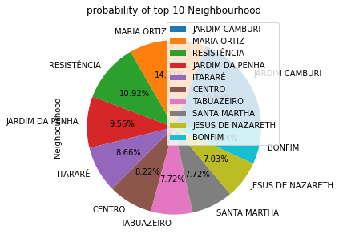

```python
# using pie chart to show top 10 most frequent hospitals
plt.figure(figsize=(10, 5))
print(df_max_10['Neighbourhood'].value_counts()/data_length)
plt.figure(figsize=(10, 5))
df_max_10['Neighbourhood'].value_counts().plot(kind='pie',autopct='%1.2f%%') ;
plt.title('probability of top 10 Neighbourhood')
plt.legend(loc='upper right') ;
```

> now let's make relationship between top 10 most frequent hospitals and show appointement

```
the probabilties of show attendant in Neighbourhood
 JARDIM CAMBURI       6252
MARIA ORTIZ          4586
RESISTÊNCIA          3525
JARDIM DA PENHA      3246
SANTA MARTHA         2635
CENTRO               2631
ITARARÉ              2591
TABUAZEIRO           2559
BONFIM               2223
JESUS DE NAZARETH    2157
Name: Neighbourhood, dtype: int64
```

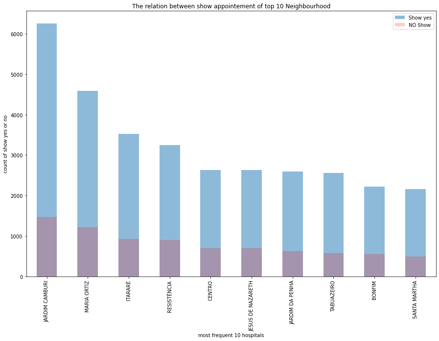

```python
### let's now show whole data in one figure
print("the probabilties of show attendant in Neighbourhood  \n",df_max_10.query('Show=="Yes"')['Neighbourhood'].value_counts())
plt.figure(figsize=(15, 10))
(df_max_10.query('Show=="Yes"')['Neighbourhood'].value_counts()).plot(kind='bar',alpha=0.5,label="Show yes")
(df_max_10.query('Show=="NO"')['Neighbourhood'].value_counts()).plot(kind='bar',color='r',alpha=0.2,label="NO Show",)
plt.xlabel("most frequent 10 hospitals")
plt.ylabel('count of show yes or no')
plt.title('The relation between show appointement of top 10 Neighbourhood')
plt.legend(loc='upper right') ;
```

## Q7)What is the mean, max, 50% precentile of day_diff

> colummn Time_diff represented system delay between scaduale day and appointement day

```python
df.head()
```

|  | Gender | ScheduledDay | AppointmentDay | Days_diff | Age | Age_sectors | Neighbourhood | Scholarship | Disease | Handcap | SMS_received | Show |
| --- | --- | --- | --- | --- | --- | --- | --- | --- | --- | --- | --- | --- |
| 0 | Female | 2016-04-29 18:38:08+00:00 | 2016-04-29 00:00:00+00:00 | -1 | 62 | [58,115] | JARDIM DA PENHA | False | True | False | NO | Yes |
| 1 | Male | 2016-04-29 16:08:27+00:00 | 2016-04-29 00:00:00+00:00 | -1 | 56 | [58,115] | JARDIM DA PENHA | False | False | False | NO | Yes |
| 2 | Female | 2016-04-29 16:19:04+00:00 | 2016-04-29 00:00:00+00:00 | -1 | 62 | [58,115] | MATA DA PRAIA | False | False | False | NO | Yes |
| 3 | Female | 2016-04-29 17:29:31+00:00 | 2016-04-29 00:00:00+00:00 | -1 | 8 | [0,19] | PONTAL DE CAMBURI | False | False | False | NO | Yes |
| 4 | Female | 2016-04-29 16:07:23+00:00 | 2016-04-29 00:00:00+00:00 | -1 | 56 | [58,115] | JARDIM DA PENHA | False | True | False | NO | Yes |

> First let's test frequencies of days_diff

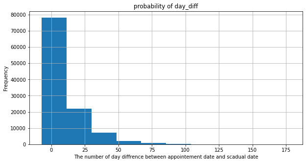

```python
# using pie chart to show top 10 most frequent hospitals
plt.figure(figsize=(10, 5))
plt.figure(figsize=(10, 5))
df['Days_diff'].hist()
plt.title('probability of day_diff')
plt.ylabel('Frequency')
plt.xlabel('The number of day diffrence between appointement date and scadual date')
```

```python
df['Days_diff'].value_counts()
```

```
-1      38562
 1       6725
 3       5290
 0       5213
 6       4906
        ...
 125        1
 81         1
 126        1
 138        1
 122        1
Name: Days_diff, Length: 131, dtype: int64
```

> wow 38562 have nagative time diff which mean scadual day after appointement days which is not correct

> that maype dta collected has some error

```python
# so let's discard negative day_diff
df_diff=df[df['Days_diff']>0]
df_diff.head()
```

|  | Gender | ScheduledDay | AppointmentDay | Days_diff | Age | Age_sectors | Neighbourhood | Scholarship | Disease | Handcap | SMS_received | Show |
| --- | --- | --- | --- | --- | --- | --- | --- | --- | --- | --- | --- | --- |
| 5 | Female | 2016-04-27 08:36:51+00:00 | 2016-04-29 00:00:00+00:00 | 1 | 76 | [58,115] | REPÚBLICA | False | True | False | NO | Yes |
| 6 | Female | 2016-04-27 15:05:12+00:00 | 2016-04-29 00:00:00+00:00 | 1 | 23 | [20,39] | GOIABEIRAS | False | False | False | NO | NO |
| 7 | Female | 2016-04-27 15:39:58+00:00 | 2016-04-29 00:00:00+00:00 | 1 | 39 | [40,57] | GOIABEIRAS | False | False | False | NO | NO |
| 9 | Female | 2016-04-27 12:48:25+00:00 | 2016-04-29 00:00:00+00:00 | 1 | 19 | [20,39] | CONQUISTA | False | False | False | NO | Yes |
| 10 | Female | 2016-04-27 14:58:11+00:00 | 2016-04-29 00:00:00+00:00 | 1 | 30 | [20,39] | NOVA PALESTINA | False | False | False | NO | Yes |

```python
df_diff['Days_diff'].describe()
```

```
count    66746.000000
mean        15.785590
std         16.590956
min          1.000000
25%          4.000000
50%         11.000000
75%         23.000000
max        178.000000
Name: Days_diff, dtype: float64
```

> from describe fiunction above

> 50 % precentile be 11 days so 50% of patients need to dealy 11 days or less

## Conclusions

> 1-The more frequent month of scadualday is May, also more frequently month of appointementday is May

> 2-The more frequently week day of scadual day is Tuesday and more frequently week day of appointement is Wednesday

> 3-all days approximatly have statistical weight near to each other except saturday approximatly nothing so that mean tha day is be the vacation of the week

> 4-sectorizing_ages bassed on summary statistics of (min,25%,50%,75%,max) make sectors have the same dense so cannot affects on biasing on results

> prior probabilities of gender (male, famale) are be 1/3 and 2/3 respectivly so here the data sample is taken baiased to worf Female than Male

> 7-Female appear more frequently to show appointement than male but this apper due to prior distribution of gender(biased toword female)

> 8-after applying get_enhanse function and normalized the two gender approximatly same probabilities to show appointement

> 9-female shows appoint ment in the three cateogries [20,39] , [40,57],[58,115] approximatly the same

> 10- male shows appointement more in sector [0,19] which what we not expected

> 11-female not show is more in sector [20,39] more than remaning sectors

> 12-male in no show in [0,19] more than remaning sectors

> 13-Approximatly 22% of dataset has one of the Hipertension diabatic or alchole one of them or more

> 14-serious disease shows mor in age sectors [57,115] then [40,57]

> 15-Approximatly 24% of patients show yes have erious disease

> 16-IN case of erious disease the more probability age_sectors to show up which have a serious disease is [58,115] sectors

> 17-In case of no disease the age_sector [0,19] has more to show up

> 18-Approximatley 9.83% of patients in dataset has a scholarship in health care system

> 19-The maost frequently sector has ascholarship in health care system is [20,39] but the minimum sector is [58,115] which mean a dengrous situiation and no data biased here because we sectroized data to overcome this biase 20-more people with no scholarship shows appointement in sectors [40,57] and [58,115] but in the age_sectors [0,19] and [20,39] patients doesnot show appointement relatied to no_show

> 21-most frequent 10 hospitals ['JARDIM CAMBURI', 'MARIA ORTIZ', 'RESISTÊNCIA', 'JARDIM DA PENHA', 'ITARARÉ', 'CENTRO', 'TABUAZEIRO', 'SANTA MARTHA', 'JESUS DE NAZARETH', 'BONFIM']

> 23-50 % precentile be 11 days so 50% of patients need to dealy 11 days or less

## Recommendation

> 1- based on 19 in conclusion i recommend to add mor age_sector[57,115] to Scholarship because most of them suffers from serious diseases

## Limitations

> 1-the dataset contain a patient his age is -1 which is unvalid

> 2- Approximatly 1/3 of dataset weight has scadualday after appointement days which is not logic

> 3-some of patient have day_diff be more than 100 days which is unlogic also

> 4-there is no information about patient salary or any state in countrey

> 5-confusion about the last column if no mean that he attend the appointement and yes mean he dosenot show the appointement